# Project: No-show appointments

- Introduction
- Data Wrangling
- Exploratory Data Analysis
- Conclusions

## Introduction

This dataset collects information from 100k medical appointments in Brazil and is focused on the question of whether or not patients show up for their appointment. The question we are trying to answer here is What factors are important for us to know in order to predict if a patient will show up for their scheduled appointment?

And every patient has its own :

- 1.PatientId / Identification of a patient.
- 2.AppointmentID / Identification of each appointment.
- 3.Gender / Male or Female.
- 4.ScheduledDay /tells us on what day the patient set up their appointment.(Registered) .
- 5.AppointmentDay / The day of the appointment.
- 6.Age / How old the patient is in years.
- 7.Neighbourhood / the location of the hospital.
- 8.Scholarship / 1 for True, 0 for False,the patient has government medical support.
- 9.Hipertension / 1 for True, 0 for False.
- 10.Diabetes / 1 for True, 0 for False.
- 11.Alcoholism / if the patient is Alcoholism; 1 for True, 0 for False.
- 12.Handcap / number of disabilities a patient has.
- 13.SMS_received / 1 for True, 0 for False.
- 14.No-show / Yes or No, if the patient showup = No, if he didn't = Yes.

Questions that we could explore:

- Does the ages of the patients affect their attendace or not?
- Does the patient who have scholarship show up or not?
- SMS_reminder helps in raising the percentage of showed up?
- Does the waiting days between Scheduled day and Appointment day affected the patients to showup?

**Importing important libraries**

```python
#Importing important libraries

import numpy as np
import pandas as pd
import matplotlib.pyplot as plt
import seaborn as sns
%matplotlib inline
```

## Data Wrangling

> Now we have our data to start work with it. Data wrangling done through three steps:
> - 1. Loading and gathering our data.
> - 1. Assess our data and find any proplems could be there.
> - 1. Clean our data from any proplems.

### General Properties

```python
#loading the data

df= pd.read_csv('no_show_appointments.csv')
df.head()
```

|  | PatientId | AppointmentID | Gender | ScheduledDay | AppointmentDay | Age | Neighbourhood | Scholarship | Hipertension | Diabetes | Alcoholism | Handcap | SMS_received | No-show |
| --- | --- | --- | --- | --- | --- | --- | --- | --- | --- | --- | --- | --- | --- | --- |
| 0 | 2.987250e+13 | 5642903 | F | 2016-04-29T18:38:08Z | 2016-04-29T00:00:00Z | 62 | JARDIM DA PENHA | 0 | 1 | 0 | 0 | 0 | 0 | No |
| 1 | 5.589978e+14 | 5642503 | M | 2016-04-29T16:08:27Z | 2016-04-29T00:00:00Z | 56 | JARDIM DA PENHA | 0 | 0 | 0 | 0 | 0 | 0 | No |
| 2 | 4.262962e+12 | 5642549 | F | 2016-04-29T16:19:04Z | 2016-04-29T00:00:00Z | 62 | MATA DA PRAIA | 0 | 0 | 0 | 0 | 0 | 0 | No |
| 3 | 8.679512e+11 | 5642828 | F | 2016-04-29T17:29:31Z | 2016-04-29T00:00:00Z | 8 | PONTAL DE CAMBURI | 0 | 0 | 0 | 0 | 0 | 0 | No |
| 4 | 8.841186e+12 | 5642494 | F | 2016-04-29T16:07:23Z | 2016-04-29T00:00:00Z | 56 | JARDIM DA PENHA | 0 | 1 | 1 | 0 | 0 | 0 | No |

```python
#show the last five rows of the data

df.tail(5)
```

|  | PatientId | AppointmentID | Gender | ScheduledDay | AppointmentDay | Age | Neighbourhood | Scholarship | Hipertension | Diabetes | Alcoholism | Handcap | SMS_received | No-show |
| --- | --- | --- | --- | --- | --- | --- | --- | --- | --- | --- | --- | --- | --- | --- |
| 110522 | 2.572134e+12 | 5651768 | F | 2016-05-03T09:15:35Z | 2016-06-07T00:00:00Z | 56 | MARIA ORTIZ | 0 | 0 | 0 | 0 | 0 | 1 | No |
| 110523 | 3.596266e+12 | 5650093 | F | 2016-05-03T07:27:33Z | 2016-06-07T00:00:00Z | 51 | MARIA ORTIZ | 0 | 0 | 0 | 0 | 0 | 1 | No |
| 110524 | 1.557663e+13 | 5630692 | F | 2016-04-27T16:03:52Z | 2016-06-07T00:00:00Z | 21 | MARIA ORTIZ | 0 | 0 | 0 | 0 | 0 | 1 | No |
| 110525 | 9.213493e+13 | 5630323 | F | 2016-04-27T15:09:23Z | 2016-06-07T00:00:00Z | 38 | MARIA ORTIZ | 0 | 0 | 0 | 0 | 0 | 1 | No |
| 110526 | 3.775115e+14 | 5629448 | F | 2016-04-27T13:30:56Z | 2016-06-07T00:00:00Z | 54 | MARIA ORTIZ | 0 | 0 | 0 | 0 | 0 | 1 | No |

```python
#explor data shape :(rows ,columns)
df.shape
```

```
(110527, 14)
```

```python
#exploration data statistical information

df.describe()
```

|  | PatientId | AppointmentID | Age | Scholarship | Hipertension | Diabetes | Alcoholism | Handcap | SMS_received |
| --- | --- | --- | --- | --- | --- | --- | --- | --- | --- |
| count | 1.105270e+05 | 1.105270e+05 | 110527.000000 | 110527.000000 | 110527.000000 | 110527.000000 | 110527.000000 | 110527.000000 | 110527.000000 |
| mean | 1.474963e+14 | 5.675305e+06 | 37.088874 | 0.098266 | 0.197246 | 0.071865 | 0.030400 | 0.022248 | 0.321026 |
| std | 2.560949e+14 | 7.129575e+04 | 23.110205 | 0.297675 | 0.397921 | 0.258265 | 0.171686 | 0.161543 | 0.466873 |
| min | 3.921784e+04 | 5.030230e+06 | -1.000000 | 0.000000 | 0.000000 | 0.000000 | 0.000000 | 0.000000 | 0.000000 |
| 25% | 4.172614e+12 | 5.640286e+06 | 18.000000 | 0.000000 | 0.000000 | 0.000000 | 0.000000 | 0.000000 | 0.000000 |
| 50% | 3.173184e+13 | 5.680573e+06 | 37.000000 | 0.000000 | 0.000000 | 0.000000 | 0.000000 | 0.000000 | 0.000000 |
| 75% | 9.439172e+13 | 5.725524e+06 | 55.000000 | 0.000000 | 0.000000 | 0.000000 | 0.000000 | 0.000000 | 1.000000 |
| max | 9.999816e+14 | 5.790484e+06 | 115.000000 | 1.000000 | 1.000000 | 1.000000 | 1.000000 | 4.000000 | 1.000000 |

```python
#general information

df.info()
```

```
<class 'pandas.core.frame.DataFrame'>
RangeIndex: 110527 entries, 0 to 110526
Data columns (total 14 columns):
 #   Column          Non-Null Count   Dtype
---  ------          --------------   -----
 0   PatientId       110527 non-null  float64
 1   AppointmentID   110527 non-null  int64
 2   Gender          110527 non-null  object
 3   ScheduledDay    110527 non-null  object
 4   AppointmentDay  110527 non-null  object
 5   Age             110527 non-null  int64
 6   Neighbourhood   110527 non-null  object
 7   Scholarship     110527 non-null  int64
 8   Hipertension    110527 non-null  int64
 9   Diabetes        110527 non-null  int64
 10  Alcoholism      110527 non-null  int64
 11  Handcap         110527 non-null  int64
 12  SMS_received    110527 non-null  int64
 13  No-show         110527 non-null  object
dtypes: float64(1), int64(8), object(5)
memory usage: 11.8+ MB
```

```python
#find the missing values in the data

df.isnull().sum()
```

```
PatientId         0
AppointmentID     0
Gender            0
ScheduledDay      0
AppointmentDay    0
Age               0
Neighbourhood     0
Scholarship       0
Hipertension      0
Diabetes          0
Alcoholism        0
Handcap           0
SMS_received      0
No-show           0
dtype: int64
```

```python
#find the duplicated data

sum(df.duplicated())
```

```
0
```

### Data Cleaning (No-show appointment data)

What I'll do..

- First, Drop unneeded columns this include:( 'PatientId', 'AppointmentID', 'Gender', 'Neighbourhood').
- second, Fix some of the columns names and put underscore.

  ```
  - In the  No-show column, 'No' means the patient showed up to their appointment,and 'Yes' means they did not             show up.
  - After changed the column to show : '1' means 'No' they showed up, and '0' means 'Yes' they didn't show up.
  - All the dataset now (1 = True) and (0 = False).
  ```

- Third, Drop the negitive value available in Age column. The describe function when we run it, shows that the Age had negitive value.
- Finally,convert the data type from string to datetime for both :('Schedualed day' and 'Appointment day')columns.

```python
#Delete unneeded columns

df.drop(['PatientId', 'AppointmentID', 'Gender', 'Neighbourhood'], axis = 1, inplace= True)
```

```python
#show the first five raws after dropping

df.head()
```

|  | ScheduledDay | AppointmentDay | Age | Scholarship | Hipertension | Diabetes | Alcoholism | Handcap | SMS_received | No-show |
| --- | --- | --- | --- | --- | --- | --- | --- | --- | --- | --- |
| 0 | 2016-04-29T18:38:08Z | 2016-04-29T00:00:00Z | 62 | 0 | 1 | 0 | 0 | 0 | 0 | No |
| 1 | 2016-04-29T16:08:27Z | 2016-04-29T00:00:00Z | 56 | 0 | 0 | 0 | 0 | 0 | 0 | No |
| 2 | 2016-04-29T16:19:04Z | 2016-04-29T00:00:00Z | 62 | 0 | 0 | 0 | 0 | 0 | 0 | No |
| 3 | 2016-04-29T17:29:31Z | 2016-04-29T00:00:00Z | 8 | 0 | 0 | 0 | 0 | 0 | 0 | No |
| 4 | 2016-04-29T16:07:23Z | 2016-04-29T00:00:00Z | 56 | 0 | 1 | 1 | 0 | 0 | 0 | No |

```python
#Fix some of the columns names and put underscores

new_columns = {'ScheduledDay':'Scheduled_Day','AppointmentDay':'Appointment_Day','Handcap':'Handicap','No-show':'show'}
df.rename(columns = new_columns , inplace = True)
```

```python
# change the show column values
# 1=show , 0= No_show

df['show'] = df['show'].apply( lambda x: 1 if x == 'No' else 0)
```

```python
#Data after the changes

df.head()
```

|  | Scheduled_Day | Appointment_Day | Age | Scholarship | Hipertension | Diabetes | Alcoholism | Handicap | SMS_received | show |
| --- | --- | --- | --- | --- | --- | --- | --- | --- | --- | --- |
| 0 | 2016-04-29T18:38:08Z | 2016-04-29T00:00:00Z | 62 | 0 | 1 | 0 | 0 | 0 | 0 | 1 |
| 1 | 2016-04-29T16:08:27Z | 2016-04-29T00:00:00Z | 56 | 0 | 0 | 0 | 0 | 0 | 0 | 1 |
| 2 | 2016-04-29T16:19:04Z | 2016-04-29T00:00:00Z | 62 | 0 | 0 | 0 | 0 | 0 | 0 | 1 |
| 3 | 2016-04-29T17:29:31Z | 2016-04-29T00:00:00Z | 8 | 0 | 0 | 0 | 0 | 0 | 0 | 1 |
| 4 | 2016-04-29T16:07:23Z | 2016-04-29T00:00:00Z | 56 | 0 | 1 | 1 | 0 | 0 | 0 | 1 |

```python
#Find the negitive value available in Age column

df_age =df.query('Age < 0')
df_age
```

|  | Scheduled_Day | Appointment_Day | Age | Scholarship | Hipertension | Diabetes | Alcoholism | Handicap | SMS_received | show |
| --- | --- | --- | --- | --- | --- | --- | --- | --- | --- | --- |
| 99832 | 2016-06-06T08:58:13Z | 2016-06-06T00:00:00Z | -1 | 0 | 0 | 0 | 0 | 0 | 0 | 1 |

```python
#Drop the negitive value available in Age column

df.drop(df_age.index, inplace= True)
```

```python
#Check the availablity of the negitive value

df_age =df.query('Age < 0')
df_age
```

|  | Scheduled_Day | Appointment_Day | Age | Scholarship | Hipertension | Diabetes | Alcoholism | Handicap | SMS_received | show |
| --- | --- | --- | --- | --- | --- | --- | --- | --- | --- | --- |

```python
#convert the data type from string to datetime for both :('Schedualed day' and 'Appointment day')columns.

df['Scheduled_Day']= pd.to_datetime(df['Scheduled_Day'])
df['Appointment_Day']= pd.to_datetime(df['Appointment_Day'])
```

```python
#Check the data types

df.dtypes
```

```
Scheduled_Day      datetime64[ns, UTC]
Appointment_Day    datetime64[ns, UTC]
Age                              int64
Scholarship                      int64
Hipertension                     int64
Diabetes                         int64
Alcoholism                       int64
Handicap                         int64
SMS_received                     int64
show                             int64
dtype: object
```

## Exploratory Data Analysis

> Now we will explore and then augment our data to maximize the potential of our analyses. This section also must walk through three steps to complete:
> - Exploring the data.
> - Visualising.
> - Conclude the findings.

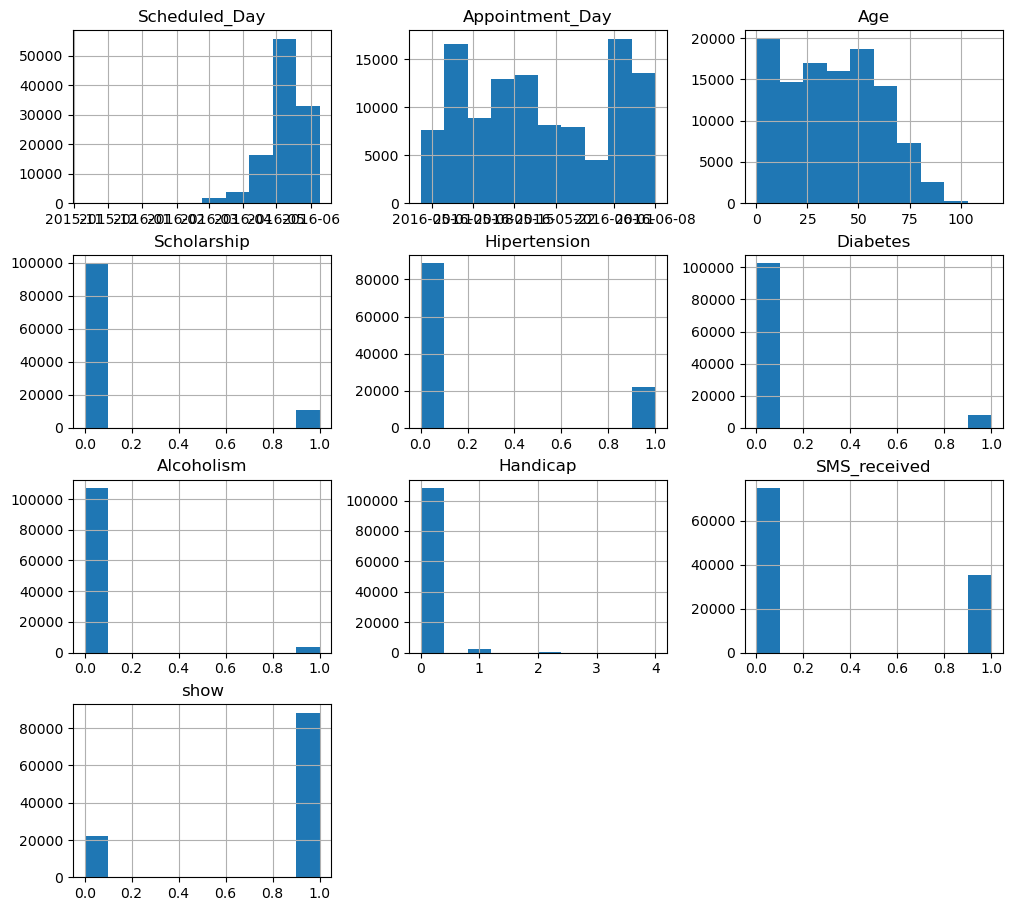

```python
#explore all data
df.hist(figsize=(12,11));
```

From the histograms it shows that, most of the patients are bellow the 60 years old means covers all stages of age between childs, yungs and elderly. Most of them doesn't suffer from any health diseases like Diabetes, Alcoholism, and Handicap.But,some of them are suffered from Hipertension. Also, highest majority of them doesn't have a scholarship and doesn't received any SMS_reminder.In addition, most of patients does not miss any appointment, means they showed up.

**Find the percentages of paitents attendace for their appointment**

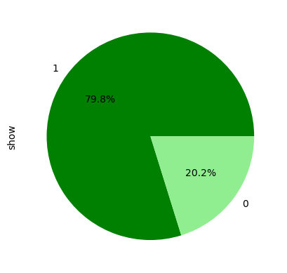

```python
df["show"].value_counts().plot(kind="pie", autopct='%1.1f%%', colors=['green', 'lightgreen'])
```

The pie above shows:

- 79.8% of paitents whos showedup for their appointment.
- 20.2% of paitents whos didn't showedup for their appointment.

  After knowing the percentage for each, let's find the factors that affected on the didn't showup percentage.

```python
#Make a mask for future use

showed = df.show == True
not_showed = df.show == False
```

### Question 1 : Does the ages of the patients affect their attendace or not?

```python
#Find showed mean for Age

df.Age[showed].mean()
```

```
37.790504154999034
```

```python
#Find not_showed mean for Age

df.Age[not_showed].mean()
```

```
34.31766656212196
```

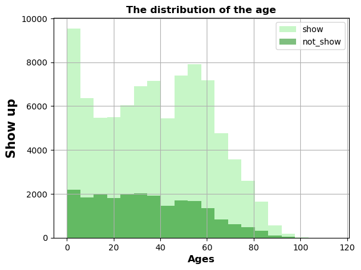

```python
#Histogram explain the correlation between the variety of ages who showed up and who didn't:

df.Age[showed].hist(alpha=0.5, bins=20, label='show', color='lightgreen')
df.Age[not_showed].hist(alpha=0.5, bins=20, label='not_show', color='green')
plt.title(" The distribution of the age ", fontsize=12,weight='bold')
plt.ylabel(' Show up ', fontsize=15,weight='bold');
plt.xlabel('Ages', fontsize=12,weight='bold');
plt.legend();
```

**We predict the age "0" revers to newborn babies.**

There is an equally distribution of all Ages till the age of 70. After the age of 70 there is less patients.

We can see there is **a relationship** between the age and show up. Age seems to be an important factor where middle-aged (mean) patients is less in not to show up with a mean of 34 years, and more they are showedup with a mean of 37 years.

### Question 2 : Does the patient who have scholarship show up or not?

```python
#Find not_showed mean for Scholarship

df.Scholarship[not_showed].mean()
```

```
0.11550696715802679
```

```python
#Define the ratio calculation, for easy calculate the up coming values
"""
    df - the original dataframe.
    column_name1 - the name of the column used to groupby data.
    column_name2 - the name of the column to get value counts.
    """

def ratio_calculate(df, column_name1, column_name2):
    ratio = df.groupby(column_name1)[column_name2].value_counts(normalize=True).unstack(column_name2)
    return ratio
```

```python
#Find the Scholarship ratio

Scholarship_ratio = ratio_calculate(df,'Scholarship',"show")
Scholarship_ratio
```

| show Scholarship | 0 | 1 |
| --- | --- | --- |
| 0 | 0.198074 | 0.801926 |
| 1 | 0.237363 | 0.762637 |

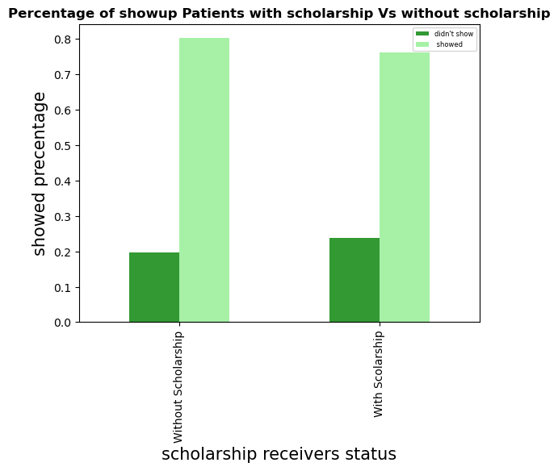

```python
#Plot bar for Scholarship ratio explor the relationship between showup vs. having Scholarship or not

Scholarship_ratio.plot(kind='bar',alpha=0.8, color= ['green','lightgreen'])
plt.title('Percentage of showup Patients with scholarship Vs without scholarship', fontsize=12,color="black",weight='bold')
plt.ylabel('showed precentage', fontsize=15,color="black");
plt.xlabel('scholarship receivers status', fontsize=15,color="black");
locations = ['Without Scholarship','With Scolarship']
plt.xticks(np.arange(len(locations)),locations);
plt.legend(["didn't show"," showed"], fontsize=6);
```

- The scholarship seems **not have a relationship** with the patients showedup. As both showed and not showed with a scholarship and without it slightly gives a close percentages. so, there is no a big difference.

### Question 3 : SMS_reminder helps in raising the percentage of showed up?

```python
#Find showed mean for SMS_received

df.SMS_received[showed].mean()
```

```
0.29133742220005215
```

```python
#Find not_showed mean for SMS_received

df.SMS_received[not_showed].mean()
```

```
0.43837089475334917
```

```python
#calculate the SMS_received ratio

SMS_received_ratio = ratio_calculate(df,'SMS_received',"show")
SMS_received_ratio
```

| show SMS_received | 0 | 1 |
| --- | --- | --- |
| 0 | 0.167035 | 0.832965 |
| 1 | 0.275745 | 0.724255 |

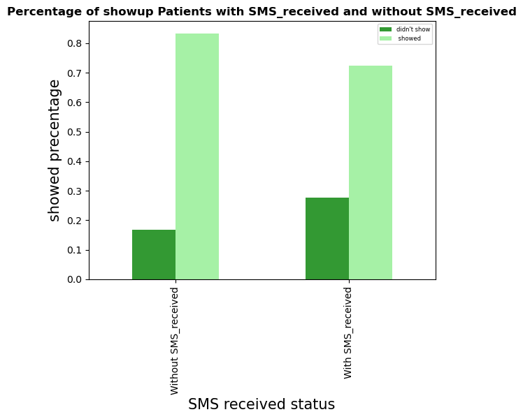

```python
#Plot bar for SMS_received ratio explor the relationship between showup vs. SMS_received or not


SMS_received_ratio.plot(kind='bar',alpha=0.8, color= ['green','lightgreen'])
plt.title('Percentage of showup Patients with SMS_received and without SMS_received', fontsize=12,color="black",weight='bold')
plt.ylabel('showed precentage', fontsize=15,color="black");
plt.xlabel('SMS received status', fontsize=15,color="black");
locations = ['Without SMS_received','With SMS_received']
plt.xticks(np.arange(len(locations)),locations);
plt.legend(["didn't show"," showed"], fontsize=6);
```

### Question 4 : Does the waiting days between Scheduled day and Appointment day affected the patients to showup?

Noticed that the last five raws in the data when I run the df.tail(5) function, there is a differences in the dates of Appointment day and Scheduled day. It seems there is a waiting days between them. Now, the exploration of the data tells us if it would be a factor of not showup.

```python
#Find the Waiting Days by Subtract Scheduled Day from Appointment Day

df['WaitingDays'] = (df['Appointment_Day'] - df['Scheduled_Day']).dt.days
waiting_days = df['WaitingDays']
```

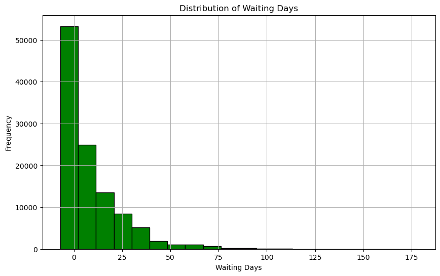

```python
#Explor the distribution of waiting days

plt.figure(figsize=(10, 6))
plt.hist(waiting_days, bins=20, edgecolor='k', color='green')
plt.title('Distribution of Waiting Days')
plt.xlabel('Waiting Days')
plt.ylabel('Frequency')
plt.grid(True)
plt.show()
```

## Conclusions

### Limitations

- The age column has value "0" which makes me cofused to what revers. I predict it would be a newborn babies.
- Most of the visuals provides very close reselts related to showup and didn't showup, that make the notice of the differences is challenged.
- The information related to the dates of appointment and Scheduled are not really clear.